# Prosper Loan Data Exploration

## Introduction

This data set contains contains loans accredited by Prosper.

## Preliminary Wrangling

```python
# import all packages and set plots to be embedded inline
import numpy as np
import pandas as pd
import matplotlib.pyplot as plt
import seaborn as sb

%matplotlib inline
```

```python
df= pd.read_csv('D:/Udacity Projects/Communicate your findings/Project Template/prosperLoanData.csv')
df.head(10)
```

|  | ListingKey | ListingNumber | ListingCreationDate | CreditGrade | Term | LoanStatus | ClosedDate | BorrowerAPR | BorrowerRate | LenderYield | ... | LP_ServiceFees | LP_CollectionFees | LP_GrossPrincipalLoss | LP_NetPrincipalLoss | LP_NonPrincipalRecoverypayments | PercentFunded | Recommendations | InvestmentFromFriendsCount | InvestmentFromFriendsAmount | Investors |
| --- | --- | --- | --- | --- | --- | --- | --- | --- | --- | --- | --- | --- | --- | --- | --- | --- | --- | --- | --- | --- | --- |
| 0 | 1021339766868145413AB3B | 193129 | 2007-08-26 19:09:29.263000000 | C | 36 | Completed | 2009-08-14 00:00:00 | 0.16516 | 0.1580 | 0.1380 | ... | -133.18 | 0.0 | 0.0 | 0.0 | 0.0 | 1.0 | 0 | 0 | 0.0 | 258 |
| 1 | 10273602499503308B223C1 | 1209647 | 2014-02-27 08:28:07.900000000 | NaN | 36 | Current | NaN | 0.12016 | 0.0920 | 0.0820 | ... | 0.00 | 0.0 | 0.0 | 0.0 | 0.0 | 1.0 | 0 | 0 | 0.0 | 1 |
| 2 | 0EE9337825851032864889A | 81716 | 2007-01-05 15:00:47.090000000 | HR | 36 | Completed | 2009-12-17 00:00:00 | 0.28269 | 0.2750 | 0.2400 | ... | -24.20 | 0.0 | 0.0 | 0.0 | 0.0 | 1.0 | 0 | 0 | 0.0 | 41 |
| 3 | 0EF5356002482715299901A | 658116 | 2012-10-22 11:02:35.010000000 | NaN | 36 | Current | NaN | 0.12528 | 0.0974 | 0.0874 | ... | -108.01 | 0.0 | 0.0 | 0.0 | 0.0 | 1.0 | 0 | 0 | 0.0 | 158 |
| 4 | 0F023589499656230C5E3E2 | 909464 | 2013-09-14 18:38:39.097000000 | NaN | 36 | Current | NaN | 0.24614 | 0.2085 | 0.1985 | ... | -60.27 | 0.0 | 0.0 | 0.0 | 0.0 | 1.0 | 0 | 0 | 0.0 | 20 |
| 5 | 0F05359734824199381F61D | 1074836 | 2013-12-14 08:26:37.093000000 | NaN | 60 | Current | NaN | 0.15425 | 0.1314 | 0.1214 | ... | -25.33 | 0.0 | 0.0 | 0.0 | 0.0 | 1.0 | 0 | 0 | 0.0 | 1 |
| 6 | 0F0A3576754255009D63151 | 750899 | 2013-04-12 09:52:56.147000000 | NaN | 36 | Current | NaN | 0.31032 | 0.2712 | 0.2612 | ... | -22.95 | 0.0 | 0.0 | 0.0 | 0.0 | 1.0 | 0 | 0 | 0.0 | 1 |
| 7 | 0F1035772717087366F9EA7 | 768193 | 2013-05-05 06:49:27.493000000 | NaN | 36 | Current | NaN | 0.23939 | 0.2019 | 0.1919 | ... | -69.21 | 0.0 | 0.0 | 0.0 | 0.0 | 1.0 | 0 | 0 | 0.0 | 1 |
| 8 | 0F043596202561788EA13D5 | 1023355 | 2013-12-02 10:43:39.117000000 | NaN | 36 | Current | NaN | 0.07620 | 0.0629 | 0.0529 | ... | -16.77 | 0.0 | 0.0 | 0.0 | 0.0 | 1.0 | 0 | 0 | 0.0 | 1 |
| 9 | 0F043596202561788EA13D5 | 1023355 | 2013-12-02 10:43:39.117000000 | NaN | 36 | Current | NaN | 0.07620 | 0.0629 | 0.0529 | ... | -16.77 | 0.0 | 0.0 | 0.0 | 0.0 | 1.0 | 0 | 0 | 0.0 | 1 |

10 rows × 81 columns

```python
df.columns
```

```
Index(['ListingKey', 'ListingNumber', 'ListingCreationDate', 'CreditGrade',
       'Term', 'LoanStatus', 'ClosedDate', 'BorrowerAPR', 'BorrowerRate',
       'LenderYield', 'EstimatedEffectiveYield', 'EstimatedLoss',
       'EstimatedReturn', 'ProsperRating (numeric)', 'ProsperRating (Alpha)',
       'ProsperScore', 'ListingCategory (numeric)', 'BorrowerState',
       'Occupation', 'EmploymentStatus', 'EmploymentStatusDuration',
       'IsBorrowerHomeowner', 'CurrentlyInGroup', 'GroupKey',
       'DateCreditPulled', 'CreditScoreRangeLower', 'CreditScoreRangeUpper',
       'FirstRecordedCreditLine', 'CurrentCreditLines', 'OpenCreditLines',
       'TotalCreditLinespast7years', 'OpenRevolvingAccounts',
       'OpenRevolvingMonthlyPayment', 'InquiriesLast6Months', 'TotalInquiries',
       'CurrentDelinquencies', 'AmountDelinquent', 'DelinquenciesLast7Years',
       'PublicRecordsLast10Years', 'PublicRecordsLast12Months',
       'RevolvingCreditBalance', 'BankcardUtilization',
       'AvailableBankcardCredit', 'TotalTrades',
       'TradesNeverDelinquent (percentage)', 'TradesOpenedLast6Months',
       'DebtToIncomeRatio', 'IncomeRange', 'IncomeVerifiable',
       'StatedMonthlyIncome', 'LoanKey', 'TotalProsperLoans',
       'TotalProsperPaymentsBilled', 'OnTimeProsperPayments',
       'ProsperPaymentsLessThanOneMonthLate',
       'ProsperPaymentsOneMonthPlusLate', 'ProsperPrincipalBorrowed',
       'ProsperPrincipalOutstanding', 'ScorexChangeAtTimeOfListing',
       'LoanCurrentDaysDelinquent', 'LoanFirstDefaultedCycleNumber',
       'LoanMonthsSinceOrigination', 'LoanNumber', 'LoanOriginalAmount',
       'LoanOriginationDate', 'LoanOriginationQuarter', 'MemberKey',
       'MonthlyLoanPayment', 'LP_CustomerPayments',
       'LP_CustomerPrincipalPayments', 'LP_InterestandFees', 'LP_ServiceFees',
       'LP_CollectionFees', 'LP_GrossPrincipalLoss', 'LP_NetPrincipalLoss',
       'LP_NonPrincipalRecoverypayments', 'PercentFunded', 'Recommendations',
       'InvestmentFromFriendsCount', 'InvestmentFromFriendsAmount',
       'Investors'],
      dtype='object')
```

```python
df.shape
```

```
(113937, 81)
```

```python
df.info()
```

```
<class 'pandas.core.frame.DataFrame'>
RangeIndex: 113937 entries, 0 to 113936
Data columns (total 81 columns):
 #   Column                               Non-Null Count   Dtype
---  ------                               --------------   -----
 0   ListingKey                           113937 non-null  object
 1   ListingNumber                        113937 non-null  int64
 2   ListingCreationDate                  113937 non-null  object
 3   CreditGrade                          28953 non-null   object
 4   Term                                 113937 non-null  int64
 5   LoanStatus                           113937 non-null  object
 6   ClosedDate                           55089 non-null   object
 7   BorrowerAPR                          113912 non-null  float64
 8   BorrowerRate                         113937 non-null  float64
 9   LenderYield                          113937 non-null  float64
```

[output cut: 73 more lines]

```python
df.describe()
```

|  | ListingNumber | Term | BorrowerAPR | BorrowerRate | LenderYield | EstimatedEffectiveYield | EstimatedLoss | EstimatedReturn | ProsperRating (numeric) | ProsperScore | ... | LP_ServiceFees | LP_CollectionFees | LP_GrossPrincipalLoss | LP_NetPrincipalLoss | LP_NonPrincipalRecoverypayments | PercentFunded | Recommendations | InvestmentFromFriendsCount | InvestmentFromFriendsAmount | Investors |
| --- | --- | --- | --- | --- | --- | --- | --- | --- | --- | --- | --- | --- | --- | --- | --- | --- | --- | --- | --- | --- | --- |
| count | 1.139370e+05 | 113937.000000 | 113912.000000 | 113937.000000 | 113937.000000 | 84853.000000 | 84853.000000 | 84853.000000 | 84853.000000 | 84853.000000 | ... | 113937.000000 | 113937.000000 | 113937.000000 | 113937.000000 | 113937.000000 | 113937.000000 | 113937.000000 | 113937.000000 | 113937.000000 | 113937.000000 |
| mean | 6.278857e+05 | 40.830248 | 0.218828 | 0.192764 | 0.182701 | 0.168661 | 0.080306 | 0.096068 | 4.072243 | 5.950067 | ... | -54.725641 | -14.242698 | 700.446342 | 681.420499 | 25.142686 | 0.998584 | 0.048027 | 0.023460 | 16.550751 | 80.475228 |
| std | 3.280762e+05 | 10.436212 | 0.080364 | 0.074818 | 0.074516 | 0.068467 | 0.046764 | 0.030403 | 1.673227 | 2.376501 | ... | 60.675425 | 109.232758 | 2388.513831 | 2357.167068 | 275.657937 | 0.017919 | 0.332353 | 0.232412 | 294.545422 | 103.239020 |
| min | 4.000000e+00 | 12.000000 | 0.006530 | 0.000000 | -0.010000 | -0.182700 | 0.004900 | -0.182700 | 1.000000 | 1.000000 | ... | -664.870000 | -9274.750000 | -94.200000 | -954.550000 | 0.000000 | 0.700000 | 0.000000 | 0.000000 | 0.000000 | 1.000000 |
| 25% | 4.009190e+05 | 36.000000 | 0.156290 | 0.134000 | 0.124200 | 0.115670 | 0.042400 | 0.074080 | 3.000000 | 4.000000 | ... | -73.180000 | 0.000000 | 0.000000 | 0.000000 | 0.000000 | 1.000000 | 0.000000 | 0.000000 | 0.000000 | 2.000000 |
| 50% | 6.005540e+05 | 36.000000 | 0.209760 | 0.184000 | 0.173000 | 0.161500 | 0.072400 | 0.091700 | 4.000000 | 6.000000 | ... | -34.440000 | 0.000000 | 0.000000 | 0.000000 | 0.000000 | 1.000000 | 0.000000 | 0.000000 | 0.000000 | 44.000000 |
| 75% | 8.926340e+05 | 36.000000 | 0.283810 | 0.250000 | 0.240000 | 0.224300 | 0.112000 | 0.116600 | 5.000000 | 8.000000 | ... | -13.920000 | 0.000000 | 0.000000 | 0.000000 | 0.000000 | 1.000000 | 0.000000 | 0.000000 | 0.000000 | 115.000000 |
| max | 1.255725e+06 | 60.000000 | 0.512290 | 0.497500 | 0.492500 | 0.319900 | 0.366000 | 0.283700 | 7.000000 | 11.000000 | ... | 32.060000 | 0.000000 | 25000.000000 | 25000.000000 | 21117.900000 | 1.012500 | 39.000000 | 33.000000 | 25000.000000 | 1189.000000 |

8 rows × 61 columns

we see that we have 81 columns and for the purpose of the project I will only take some variables and drop the rest.

```python
# adding our chosen columns to a list
project_columns =  ['BorrowerRate', 'ProsperRating (Alpha)', 'ListingCategory (numeric)', 'EmploymentStatus',
                   'StatedMonthlyIncome', 'TotalProsperLoans', 'LoanOriginalAmount',
                   'LoanOriginationDate','Term', 'LoanStatus']
```

```python
# creating new dataframe with our selected columns
project_df= df[project_columns]
```

```python
project_df.sample(20)
```

|  | BorrowerRate | ProsperRating (Alpha) | ListingCategory (numeric) | EmploymentStatus | StatedMonthlyIncome | TotalProsperLoans | LoanOriginalAmount | LoanOriginationDate | Term | LoanStatus |
| --- | --- | --- | --- | --- | --- | --- | --- | --- | --- | --- |
| 108267 | 0.1600 | NaN | 0 | Full-time | 3412.500000 | NaN | 7600 | 2007-10-02 00:00:00 | 36 | Completed |
| 111983 | 0.2899 | D | 1 | Employed | 1000.000000 | NaN | 10000 | 2011-04-01 00:00:00 | 60 | Completed |
| 18051 | 0.1239 | A | 3 | Employed | 15000.000000 | NaN | 23000 | 2014-01-16 00:00:00 | 60 | Current |
| 66102 | 0.1765 | C | 1 | Employed | 4333.333333 | NaN | 4000 | 2014-01-07 00:00:00 | 36 | Current |
| 80264 | 0.0900 | NaN | 0 | Not available | 2000.000000 | NaN | 3000 | 2006-10-11 00:00:00 | 36 | Completed |
| 113480 | 0.1795 | C | 1 | Employed | 6000.000000 | NaN | 15000 | 2014-01-21 00:00:00 | 36 | Current |
| 86769 | 0.2774 | E | 1 | Employed | 3383.333333 | NaN | 10000 | 2014-01-28 00:00:00 | 36 | Completed |
| 56465 | 0.2019 | C | 14 | Employed | 11666.666667 | 1.0 | 3000 | 2012-09-25 00:00:00 | 36 | Current |
| 63314 | 0.1500 | B | 1 | Self-employed | 15000.000000 | NaN | 15000 | 2013-12-05 00:00:00 | 36 | Current |
| 102140 | 0.1250 | NaN | 0 | Full-time | 5000.000000 | NaN | 2000 | 2007-12-03 00:00:00 | 36 | Chargedoff |
| 41432 | 0.2499 | D | 1 | Employed | 5333.333333 | 1.0 | 7500 | 2011-01-25 00:00:00 | 36 | Completed |
| 74414 | 0.1599 | NaN | 0 | Full-time | 3000.000000 | NaN | 8500 | 2007-10-10 00:00:00 | 36 | Chargedoff |
| 15556 | 0.1355 | B | 1 | Employed | 5750.000000 | 1.0 | 20000 | 2014-02-28 00:00:00 | 60 | Current |
| 103021 | 0.1350 | NaN | 0 | Full-time | 1960.000000 | NaN | 7500 | 2007-05-22 00:00:00 | 36 | Completed |
| 112594 | 0.3177 | HR | 20 | Employed | 7500.000000 | NaN | 4000 | 2012-09-05 00:00:00 | 36 | Current |
| 31375 | 0.3200 | HR | 3 | Full-time | 6666.666667 | 1.0 | 7500 | 2010-12-06 00:00:00 | 36 | Completed |
| 15541 | 0.2045 | C | 1 | Employed | 3250.000000 | NaN | 10000 | 2013-10-22 00:00:00 | 60 | Current |
| 106196 | 0.3450 | NaN | 1 | Full-time | 4250.000000 | 1.0 | 2500 | 2008-08-26 00:00:00 | 36 | Completed |
| 45552 | 0.3177 | HR | 15 | Employed | 1916.666667 | NaN | 2000 | 2012-12-21 00:00:00 | 36 | Current |
| 96660 | 0.1620 | B | 1 | Employed | 3583.333333 | NaN | 6000 | 2013-11-05 00:00:00 | 36 | Current |

```python
project_df.info()
```

```
<class 'pandas.core.frame.DataFrame'>
RangeIndex: 113937 entries, 0 to 113936
Data columns (total 10 columns):
 #   Column                     Non-Null Count   Dtype
---  ------                     --------------   -----
 0   BorrowerRate               113937 non-null  float64
 1   ProsperRating (Alpha)      84853 non-null   object
 2   ListingCategory (numeric)  113937 non-null  int64
 3   EmploymentStatus           111682 non-null  object
 4   StatedMonthlyIncome        113937 non-null  float64
 5   TotalProsperLoans          22085 non-null   float64
 6   LoanOriginalAmount         113937 non-null  int64
 7   LoanOriginationDate        113937 non-null  object
 8   Term                       113937 non-null  int64
 9   LoanStatus                 113937 non-null  object
dtypes: float64(3), int64(3), object(4)
memory usage: 8.7+ MB
```

we have NULL values and I will drop them to make sure our results are as accurate as possible.

```python
# dropping all the null values from our dataset
project_df.dropna(inplace=True)
```

```python
project_df.info()
```

```
<class 'pandas.core.frame.DataFrame'>
Int64Index: 19797 entries, 4 to 113935
Data columns (total 10 columns):
 #   Column                     Non-Null Count  Dtype
---  ------                     --------------  -----
 0   BorrowerRate               19797 non-null  float64
 1   ProsperRating (Alpha)      19797 non-null  object
 2   ListingCategory (numeric)  19797 non-null  int64
 3   EmploymentStatus           19797 non-null  object
 4   StatedMonthlyIncome        19797 non-null  float64
 5   TotalProsperLoans          19797 non-null  float64
 6   LoanOriginalAmount         19797 non-null  int64
 7   LoanOriginationDate        19797 non-null  object
 8   Term                       19797 non-null  int64
 9   LoanStatus                 19797 non-null  object
dtypes: float64(3), int64(3), object(4)
memory usage: 1.7+ MB
```

```python
# change LoanOriginationDate column to datetime data type
project_df['LoanOriginationDate'] = pd.to_datetime(project_df['LoanOriginationDate'])
```

```python
project_df.info()
```

```
<class 'pandas.core.frame.DataFrame'>
Int64Index: 19797 entries, 4 to 113935
Data columns (total 10 columns):
 #   Column                     Non-Null Count  Dtype
---  ------                     --------------  -----
 0   BorrowerRate               19797 non-null  float64
 1   ProsperRating (Alpha)      19797 non-null  object
 2   ListingCategory (numeric)  19797 non-null  int64
 3   EmploymentStatus           19797 non-null  object
 4   StatedMonthlyIncome        19797 non-null  float64
 5   TotalProsperLoans          19797 non-null  float64
 6   LoanOriginalAmount         19797 non-null  int64
 7   LoanOriginationDate        19797 non-null  datetime64[ns]
 8   Term                       19797 non-null  int64
 9   LoanStatus                 19797 non-null  object
dtypes: datetime64[ns](1), float64(3), int64(3), object(3)
memory usage: 1.7+ MB
```

### What is/are the main feature(s) of interest in your dataset?

the features of interest are the prosper rating and its relatioship with other factors. Also the loan status and the ability to predict which may be completed and which may be defaulted.

### What features in the dataset do you think will help support your investigation into your feature(s) of interest?

I think the borrow rate and the prosperrating will be depending on the income and the employments status, and that would support the investigation. Also the loan amount should make a huge impact on the result.

## Univariate Exploration

### Loan Status

#### Question: how are the Loan status distributed?

```python
def cat_bar_plot(df, column, gen_order): # defining a function that plots a bar for a categorical univariate

    base_color= sb.color_palette()[0] # choosing the color
    plt.xticks(rotation= 90) # rotating the xticks so they can be readable
    sb.countplot(data=df, x= column, color=base_color, order=gen_order); # plotting the bars
    plt.title(column)
```

```python
project_df['LoanStatus'].unique()
```

```
array(['Current', 'Completed', 'Past Due (16-30 days)', 'Chargedoff',
       'Defaulted', 'Past Due (1-15 days)', 'Past Due (61-90 days)',
       'Past Due (31-60 days)', 'FinalPaymentInProgress',
       'Past Due (91-120 days)', 'Past Due (>120 days)'], dtype=object)
```

```python
_order= ['Completed','FinalPaymentInProgress', 'Current', 'Past Due (1-15 days)',
            'Past Due (16-30 days)', 'Past Due (31-60 days)',
            'Past Due (61-90 days)', 'Past Due (91-120 days)',
            'Past Due (>120 days)','Defaulted', 'Chargedoff']
# ordering the data
```

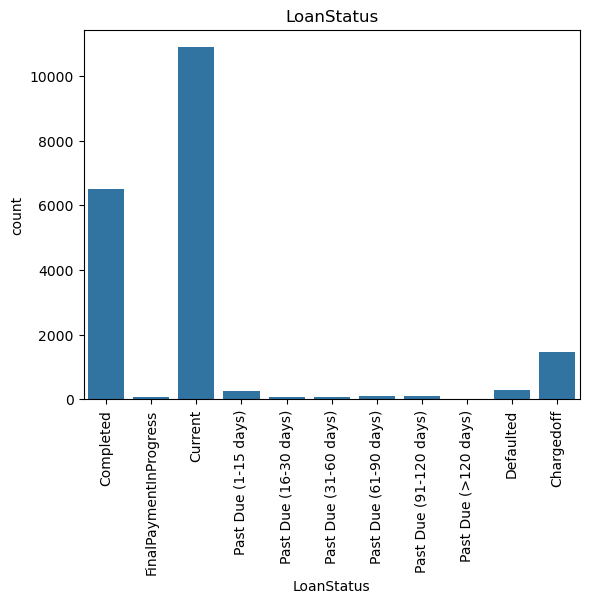

```python
cat_bar_plot(project_df, 'LoanStatus', _order)
```

1st Observation:

- I can see here that most of the loans are current.
- Also a high amount of the loans are completed.
- The charged off loans are low but not as low as the defaulted loans.
- lastly we have the past due loans which are split into groups based on a range of days.

### Prosper Rating

#### Question: What is the highest and lowest amount of rating?

```python
project_df['ProsperRating (Alpha)'].unique()
```

```
array(['D', 'E', 'AA', 'A', 'B', 'C', 'HR'], dtype=object)
```

```python
_order2= ['AA', 'A', 'B', 'C', 'D', 'E', 'HR'] # ordering the data
```

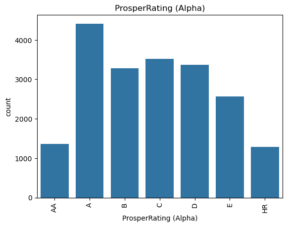

```python
cat_bar_plot(project_df, 'ProsperRating (Alpha)', _order2)
```

2nd Observation:

- I found that category A is the highest and HR is the lowest.

### Employment Status

#### Question: Which employment status has been given more loans? and which is the lowest?

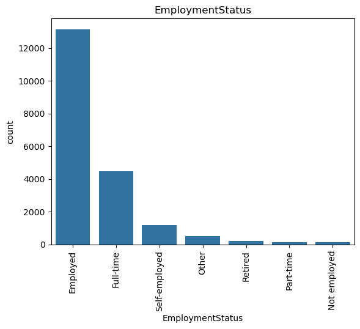

```python
cat_bar_plot(project_df, 'EmploymentStatus', project_df['EmploymentStatus'].value_counts().index)
```

3rd Observation:

- As expected, people who are Employed are the majority and Not-Employed are the least.
- From the rest of the minorities, the Full-time is the highest.

### Stated Monthly Income

#### Question: how is the monthly income distributed?

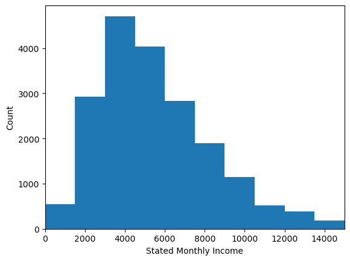

```python
plt.hist(data=project_df, x='StatedMonthlyIncome', bins=100);
plt.xlim(0,15000);
plt.xlabel('Stated Monthly Income')
plt.ylabel('Count');
```

4th Observation:

- The Monthly Income is right skewed and the its peak is at 4000.

### Loan Original Amount

#### Question: What are the loans original amount?

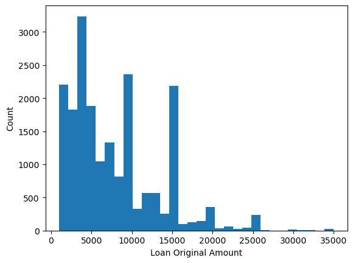

```python
plt.hist(data=project_df, x='LoanOriginalAmount', bins= 30);
plt.xlabel('Loan Original Amount')
plt.ylabel('Count');
```

5th Observation:

- The loan amount is right skewed and it has 3 spikes at 4000, 9000 and 15000.

### Discuss the distribution(s) of your variable(s) of interest. Were there any unusual points? Did you need to perform any transformations?

The stated monthly income has strange outliers so I had to limit the plot to 15000 maximum. The majority of loans are current loans and the majority of borrowers are employed. I found that the highest prosper rating is 'A' and also found 3 spikes in the loan amounts.

### Of the features you investigated, were there any unusual distributions? Did you perform any operations on the data to tidy, adjust, or change the form of the data? If so, why did you do this?

Most of the loans are current loans and they won't help predicting outcomes.

## Bivariate Exploration

```python
# checking unique status
project_df.LoanStatus.unique()
```

```
array(['Current', 'Completed', 'Past Due (16-30 days)', 'Chargedoff',
       'Defaulted', 'Past Due (1-15 days)', 'Past Due (61-90 days)',
       'Past Due (31-60 days)', 'FinalPaymentInProgress',
       'Past Due (91-120 days)', 'Past Due (>120 days)'], dtype=object)
```

```python
# Separating Loan Status
project_df= project_df.loc[(project_df['LoanStatus'] == "Defaulted") | (project_df['LoanStatus'] == "Chargedoff") | \
                           (project_df['LoanStatus'] == "Completed")]
```

```python
# Change the word Chargedoff to Defaulted
project_df["LoanStatus"]= project_df["LoanStatus"].str.replace("Chargedoff", "Defaulted", case = False)
```

No I have separated the completed and defaulted loans

```python
project_df['LoanStatus'].value_counts()
```

```
Completed    6494
Defaulted    1757
Name: LoanStatus, dtype: int64
```

```python
project_df['ListingCategory (numeric)'].value_counts()
```

```
1     4151
7     1300
2      972
3      746
6      451
15     139
13     118
5       99
18      73
19      55
20      44
14      37
16      18
8       13
11       9
9        6
12       6
17       5
0        5
10       4
Name: ListingCategory (numeric), dtype: int64
```

as we see the highest 5 categories are 1,2,3,6 & 7 which are Debt Consolidation, Home Improvement, Business, Auto and Other.

```python
# rechaping the loan categories to keep the highest categories and add the rest to the 'other'
categories_dict = {1: 'Debt Consolidation', 2: 'Home Improvement', 3: 'Business', 6: 'Auto', 7: 'Other'}

def categorize(df):
    loan_category = df['ListingCategory (numeric)']
    if  loan_category in categories_dict:
        return categories_dict[loan_category]
    else:
        return categories_dict[7]

project_df['ListingCategory (numeric)'] = project_df.apply(categorize, axis=1)
project_df['ListingCategory (numeric)'].value_counts()
```

```
Debt Consolidation    4151
Other                 1931
Home Improvement       972
Business               746
Auto                   451
Name: ListingCategory (numeric), dtype: int64
```

### Loan Status and Listing Categories

#### Question: Which categories are paying there loans and which are not?

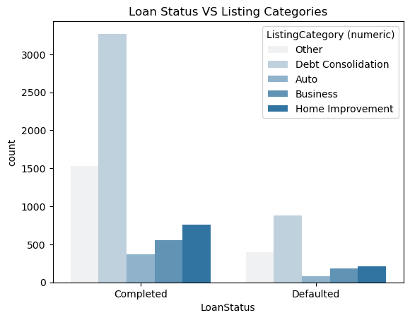

```python
base_color = sb.color_palette()[0]
sb.countplot(data=project_df, x='LoanStatus', hue='ListingCategory (numeric)', color=base_color);
plt.title('Loan Status VS Listing Categories');
```

1st observation:

- The highest amount of completed loans are from the Debt Consolidation and least in from the Auto.
- The same statistics apply for the Defaulted loans as well.

### Loan Status and Prosper Rating

#### Question: What's the most frequent rating in the completed and defaulted loans?

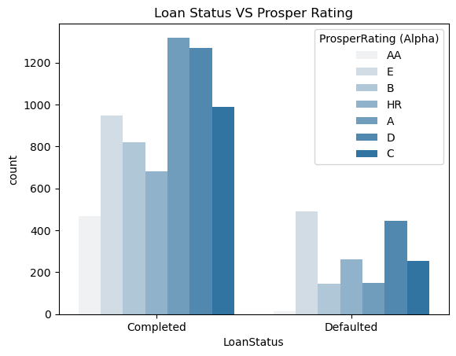

```python
base_color = sb.color_palette()[0]
sb.countplot(data=project_df, x='LoanStatus', hue='ProsperRating (Alpha)', color=base_color);
plt.title('Loan Status VS Prosper Rating');
```

### Loan Status and Loan Amount

#### Question: Are the defaulted loans bigger or the completed loans?

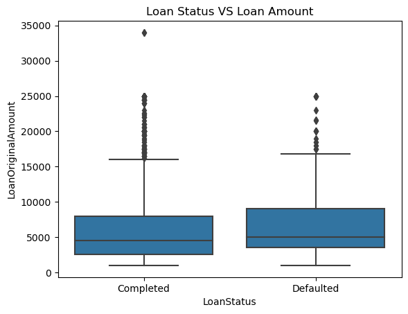

```python
sb.boxplot(data=project_df, x='LoanStatus', y='LoanOriginalAmount', color= base_color);
plt.title('Loan Status VS Loan Amount');
```

3rd observation:

- It looks like the defaulted loans are larger than the completed loans

### Stated Monthly Income and Prosper Rating

#### Question: Which rating has the highest income and which has the lowest?

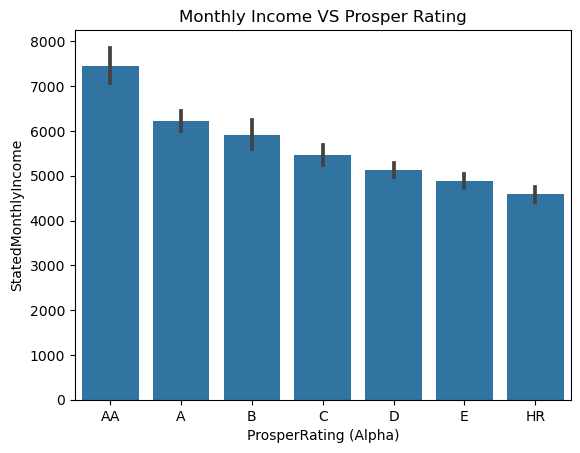

```python
_order2= ['AA', 'A', 'B', 'C', 'D', 'E', 'HR'] # ordering the data
sb.barplot(data=project_df, x='ProsperRating (Alpha)', y='StatedMonthlyIncome', color=base_color, order= _order2);
plt.title('Monthly Income VS Prosper Rating');
```

4th observation:

- The highest income is directly related to prosper rating AA and the lowest is HR then E

### Loan Status and Employmeny Status

#### Question: Does the employment status varies between completed and defaulted loans?

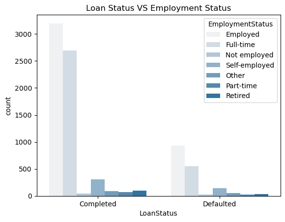

```python
sb.countplot(data=project_df, x='LoanStatus', hue='EmploymentStatus', color=base_color);
plt.title('Loan Status VS Employment Status');
```

5th observation:

- Employed, Full time and self employed are the highest in both completed and defaulted loans

### Prosper Rating and Employment Status

#### Question: What is the relationship between the unemployment and the rating?

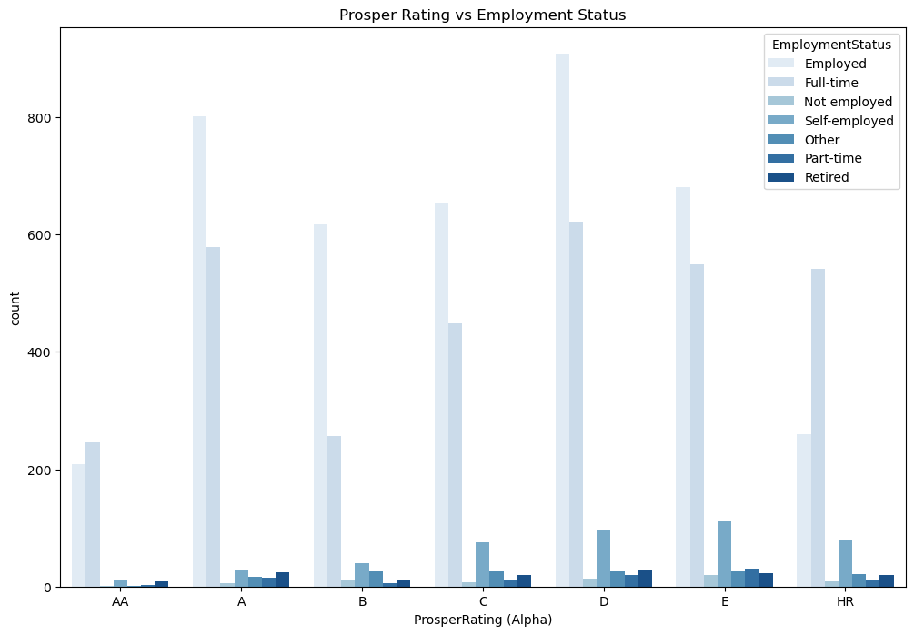

```python
_order2= ['AA', 'A', 'B', 'C', 'D', 'E', 'HR'] # ordering the data

plt.figure(figsize = [12, 8])
sb.countplot(data = project_df, x = 'ProsperRating (Alpha)', hue = 'EmploymentStatus', palette = 'Blues', order= _order2);
plt.title('Prosper Rating vs Employment Status');
```

6th observation:

- Higher ratings have lower unemployed status. AA almot doesn't have any unemployed status.

### Talk about some of the relationships you observed in this part of the investigation. How did the feature(s) of interest vary with other features in the dataset?

Employed, Full time nad self employed represents most of our data. The second lowest monthly income is rated E

### Did you observe any interesting relationships between the other features (not the main feature(s) of interest)?

The most frequent rating in the defaulted loans is E

## Multivariate Exploration

### Emplyment Status, Loan Amount and Loan Status

#### Question: Are defaulted loans bigger than completed loans in each employment status? Which employment status has bigger loan original amount?

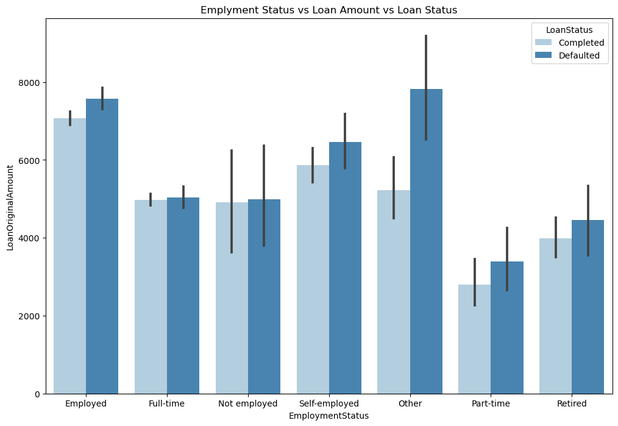

```python
plt.figure(figsize = [12, 8])
sb.barplot(data=project_df, x='EmploymentStatus', y='LoanOriginalAmount', hue='LoanStatus', palette = 'Blues');
plt.title('Emplyment Status vs Loan Amount vs Loan Status');
```

1st observation:

- Defaulted loans are larger than completed loans
- big loans tends to be for employed then self employed.
- also some big loans were assigned to 'other' and its percentage of defaulted loans is high.

### Prosper Rating, Loan Amount and Loan Status

#### Question: Are defaulted loans bigger than completed loans in each prosper rating? Which rating has the highest defaulted loans?

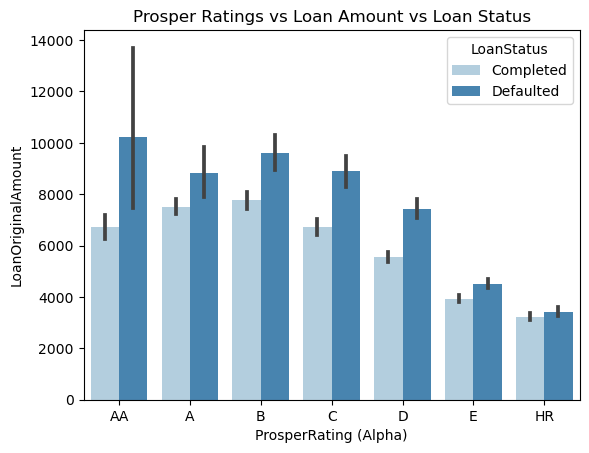

```python
_order2= ['AA', 'A', 'B', 'C', 'D', 'E', 'HR']
sb.barplot(data=project_df, x='ProsperRating (Alpha)', y='LoanOriginalAmount', hue='LoanStatus',
           palette = 'Blues', order= _order2);
plt.title('Prosper Ratings vs Loan Amount vs Loan Status');
```

2nd observation:

- defaulted loans are larger than completed ones.
- AA rating seems to have higher defaulted loans with higher outliers

### Listing Categories, Loan Amount and Loan Status

#### Question: Are defaulted loans bigger than completed loans in each listing categories? Which category has the highest loan original amount?

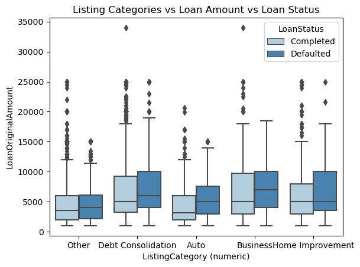

```python
sb.boxplot(data=project_df, x='ListingCategory (numeric)', y='LoanOriginalAmount', hue='LoanStatus', palette = 'Blues');
plt.title('Listing Categories vs Loan Amount vs Loan Status');
```

3rd observation:

- Defaulted loans tends to be higher than completed loans in all categories
- Business category seems to have the highest amount

### Listing Categories, Prosper Rating and Loan Status

#### Question: what is the ratio between the defaulted and completed loans in all categories?

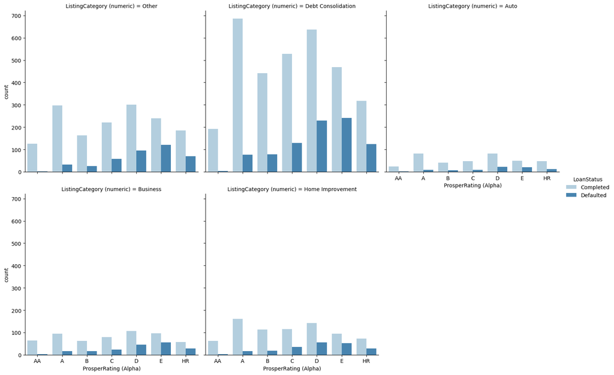

```python
sb.catplot(x = 'ProsperRating (Alpha)', hue = 'LoanStatus', col = 'ListingCategory (numeric)',data = project_df,
           kind = 'count', col_wrap = 3, palette = 'Blues', order= _order2);
```

4th observation:

- the ratio between the defaulted and completed loans looks the same in all categories.

### Talk about some of the relationships you observed in this part of the investigation. Were there features that strengthened each other in terms of looking at your feature(s) of interest?

Defaults are more in lowers rates, other employment status seems to affect the ratio between defaulted and completed loans, and finally, business category has the highest loam amount.